# training the bear classifier with different dataset sizes

vishal bakshi  
september 5, 2020

jeremy howard urges students (and practitioners) not to overestimate the amount of data that is needed to train a high performing model given that we can use transfer learning. i want to experiment with that concept by training an image classifier for the following number of images and compare the results:

- 10
- 20
- 50
- 100

```python
#!tar chvfz notebook.tar.gz *
```

```python
from utils import *
from fastai.vision.all import *
from fastai.vision.widgets import *
```

first, i'll check to see that i placed the images into the correct folders

```python
Image.open('bears2/grizzly/00000000.jpg').to_thumb(128,128)
```

[output not shown]

```python
Image.open('bears2/black/00000000.jpg').to_thumb(128,128)
```

[output not shown]

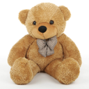

```python
Image.open('bears2/teddy/00000000.jpg').to_thumb(128,128)
```

```python
bears = DataBlock(
    blocks=(ImageBlock, CategoryBlock),
    get_items=get_image_files,
    splitter=RandomSplitter(valid_pct=0.2, seed=42),
    get_y=parent_label,
    item_tfms=Resize(128))
```

before i move on, i want to understand the `DataBlock` a bit more. so far, it's an empty container with two blocks (`ImageBlock` and `CategoryBlock`), a function to get items to store in the `DataBlock` (`get_image_files`), a function to split the items into a training and validation set `RandomSplitter`, a function to get the dependent variable y (`parent_label`) and a transform to apply to each item (`Resize()`)

```
# of total images: 30
# of training images: 24
# of validation images: 6
image labels:  black , grizzly , teddy
image after item_tfms is applied to it (PILImage mode=RGB size=128x128, TensorCategory(0))
```

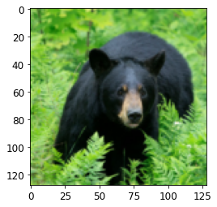

```python
path = Path('bears2')
print('# of total images:',len(bears.get_items(path)))
print('# of training images:',len(bears.splitter(bears.get_items(path))[0]))
print('# of validation images:',len(bears.splitter(bears.get_items(path))[1]))
print('image labels: ',
      bears.get_y(bears.get_items(path)[0]),",",
      bears.get_y(bears.get_items(path)[10]),",",
      bears.get_y(bears.get_items(path)[20]))
print('image after item_tfms is applied to it',bears.item_tfms[1](bears.datasets(path)[0]))
plt.imshow(bears.item_tfms[1](bears.datasets(path)[0])[0])
```

## 10 images per class

```python
dls = bears.dataloaders(path, batch_size=2)
```

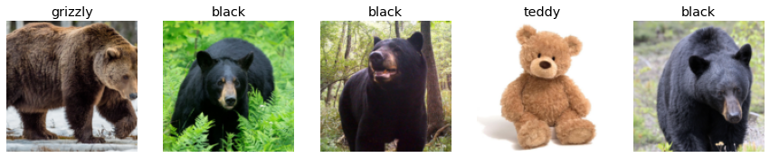

```python
dls.valid.show_batch(max_n=5,nrows=1)
```

```python
learn = cnn_learner(dls, resnet18, metrics=error_rate)
learn.fine_tune(4)
```

| epoch | train_loss | valid_loss | error_rate | time |
| --- | --- | --- | --- | --- |
| 0 | 2.640413 | 2.023208 | 0.500000 | 00:02 |

| epoch | train_loss | valid_loss | error_rate | time |
| --- | --- | --- | --- | --- |
| 0 | 1.604320 | 1.237319 | 0.500000 | 00:02 |
| 1 | 1.296324 | 0.575800 | 0.333333 | 00:02 |
| 2 | 0.932348 | 0.318487 | 0.333333 | 00:02 |
| 3 | 1.005771 | 0.664139 | 0.333333 | 00:02 |

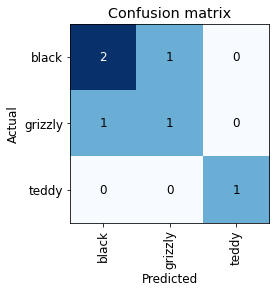

```python
interp = ClassificationInterpretation.from_learner(learn)
interp.plot_confusion_matrix()
```

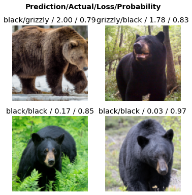

```python
interp.plot_top_losses(4, nrows=2)
```

with 10 images per class, the learner classified 4 out of 6 images correctly. i've created another folder called `bears3` with 20 images per class.

```python
import tarfile
bears_tar = tarfile.open('bears.tar.gz')
bears_tar.extractall('bears_untarred')
bears_tar.close()
```

```python
# 20 images per class
path = Path('bears_untarred/bears/bears3')
```

```python
# 50 images per class
path = Path('bears_untarred/bears/bears4')
```

```python
# 100 images per class
path = Path('bears_untarred/bears/bears5')
```

## 20 images per class

| epoch | train_loss | valid_loss | error_rate | time |
| --- | --- | --- | --- | --- |
| 0 | 1.931452 | 0.032323 | 0.000000 | 00:03 |

| epoch | train_loss | valid_loss | error_rate | time |
| --- | --- | --- | --- | --- |
| 0 | 0.641129 | 0.034566 | 0.000000 | 00:03 |
| 1 | 0.808989 | 0.070871 | 0.000000 | 00:03 |
| 2 | 0.610276 | 0.069472 | 0.000000 | 00:04 |
| 3 | 0.494522 | 0.076833 | 0.000000 | 00:03 |

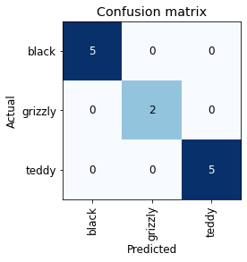

```python
learn = cnn_learner(dls, resnet18, metrics=error_rate)
learn.fine_tune(4)
interp = ClassificationInterpretation.from_learner(learn)
interp.plot_confusion_matrix()
```

the model classified the 12 validation images with 100% accuracy. this feels too good to be true. next, i train the model with 50 images per class...

## 50 images per class

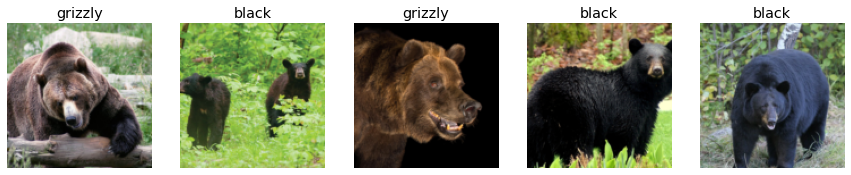

```python
dls = bears.dataloaders(path, batch_size=4)
dls.valid.show_batch(max_n=5,nrows=1)
```

| epoch | train_loss | valid_loss | error_rate | time |
| --- | --- | --- | --- | --- |
| 0 | 1.135584 | 0.107189 | 0.033333 | 00:04 |

| epoch | train_loss | valid_loss | error_rate | time |
| --- | --- | --- | --- | --- |
| 0 | 0.598698 | 0.021654 | 0.000000 | 00:05 |
| 1 | 0.352865 | 0.037703 | 0.033333 | 00:04 |
| 2 | 0.308418 | 0.025795 | 0.000000 | 00:04 |
| 3 | 0.311057 | 0.082906 | 0.033333 | 00:05 |

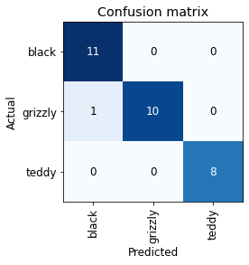

```python
learn = cnn_learner(dls, resnet18, metrics=error_rate)
learn.fine_tune(4)
interp = ClassificationInterpretation.from_learner(learn)
interp.plot_confusion_matrix()
```

interestingly enough, the model incorrectly classified one image. let's take a look at that image

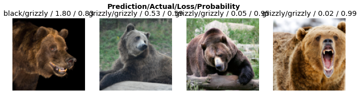

```python
interp.plot_top_losses(4, nrows=1)
```

the image that was incorrectly classified had a grizzly bear with a black background. i wonder if that activated something in the model to classify it as a black bear? let's see if the model incorrectly classifies it in the next round, with 100 images per class:

| epoch | train_loss | valid_loss | error_rate | time |
| --- | --- | --- | --- | --- |
| 0 | 0.804155 | 0.203701 | 0.066667 | 00:04 |

| epoch | train_loss | valid_loss | error_rate | time |
| --- | --- | --- | --- | --- |
| 0 | 0.443487 | 0.192606 | 0.100000 | 00:04 |
| 1 | 0.421182 | 0.194454 | 0.066667 | 00:04 |
| 2 | 0.370157 | 0.162938 | 0.066667 | 00:04 |
| 3 | 0.373813 | 0.284974 | 0.133333 | 00:04 |

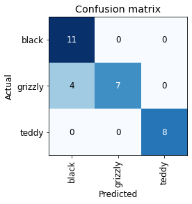

```python
learn = cnn_learner(dls, resnet18, metrics=error_rate)
learn.fine_tune(4)
interp = ClassificationInterpretation.from_learner(learn)
interp.plot_confusion_matrix()
```

the model continues to get worse....

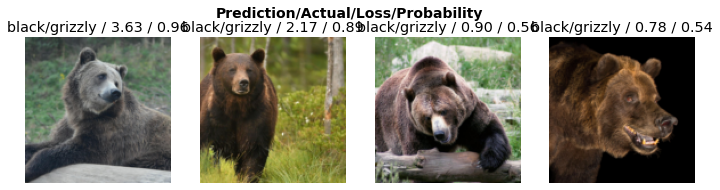

```python
interp.plot_top_losses(4, nrows=1)
```

i'm going to take a look at the images to see if there's something off in the training set

```python
cleaner = ImageClassifierCleaner(learn)
cleaner
```

there seems to be a grizzly bear in the black bear training folder. i'll delete it and re-train the model

```python
for idx in cleaner.delete(): cleaner.fns[idx].unlink()
for idx,cat in cleaner.change(): shutil.move(str(cleaner.fns[idx]), path/cat)
```

## 100 images per class

| epoch | train_loss | valid_loss | error_rate | time |
| --- | --- | --- | --- | --- |
| 0 | 0.856722 | 0.066660 | 0.016949 | 00:06 |

| epoch | train_loss | valid_loss | error_rate | time |
| --- | --- | --- | --- | --- |
| 0 | 0.500646 | 0.031495 | 0.016949 | 00:06 |
| 1 | 0.512817 | 0.141601 | 0.067797 | 00:06 |
| 2 | 0.508669 | 0.043038 | 0.016949 | 00:06 |
| 3 | 0.451077 | 0.086183 | 0.016949 | 00:06 |

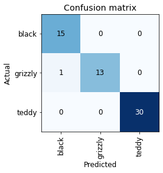

```python
dls = bears.dataloaders(path, batch_size=4)
learn = cnn_learner(dls, resnet18, metrics=error_rate)
learn.fine_tune(4)
interp = ClassificationInterpretation.from_learner(learn)
interp.plot_confusion_matrix()
```

if you noticed above in the training prior to this, i forgot to load the the 100 image path so i was really looking at the 50-image per class results. so i'll have to delete the grizzlies hanging out in the black bear folder and re-train this 100-image-per-class model

```python
cleaner = ImageClassifierCleaner(learn)
cleaner
```

there are two grizzlies that i have set to Delete

```python
for idx in cleaner.delete(): cleaner.fns[idx].unlink()
```

| epoch | train_loss | valid_loss | error_rate | time |
| --- | --- | --- | --- | --- |
| 0 | 0.951720 | 0.059914 | 0.016949 | 00:08 |

| epoch | train_loss | valid_loss | error_rate | time |
| --- | --- | --- | --- | --- |
| 0 | 0.644769 | 0.106479 | 0.033898 | 00:08 |
| 1 | 0.629878 | 0.094792 | 0.050847 | 00:08 |
| 2 | 0.484150 | 0.140442 | 0.033898 | 00:08 |
| 3 | 0.492107 | 0.155701 | 0.033898 | 00:08 |

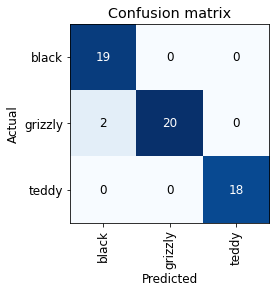

```python
dls = bears.dataloaders(path, batch_size=4)
learn = cnn_learner(dls, resnet18, metrics=error_rate)
learn.fine_tune(4)
interp = ClassificationInterpretation.from_learner(learn)
interp.plot_confusion_matrix()
```

let's see what's going on (probably the same issue)

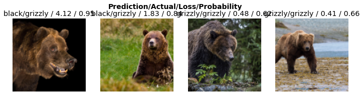

```python
interp.plot_top_losses(4, nrows=1)
```

```python
cleaner = ImageClassifierCleaner(learn)
cleaner
```

i have a hunch that something about the black background (or padding) in some of the images is causing this issue. i'll remove images from the grizzly train set that have a black background and re-train the model

```python
for idx in cleaner.delete(): cleaner.fns[idx].unlink()
```

| epoch | train_loss | valid_loss | error_rate | time |
| --- | --- | --- | --- | --- |
| 0 | 1.031428 | 0.018087 | 0.000000 | 00:05 |

| epoch | train_loss | valid_loss | error_rate | time |
| --- | --- | --- | --- | --- |
| 0 | 0.554820 | 0.018494 | 0.000000 | 00:06 |
| 1 | 0.744117 | 0.039934 | 0.017241 | 00:06 |
| 2 | 0.549703 | 0.019456 | 0.000000 | 00:06 |
| 3 | 0.531256 | 0.040601 | 0.017241 | 00:06 |

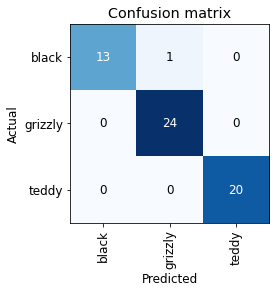

```python
dls = bears.dataloaders(path, batch_size=4)
learn = cnn_learner(dls, resnet18, metrics=error_rate)
learn.fine_tune(4)
interp = ClassificationInterpretation.from_learner(learn)
interp.plot_confusion_matrix()
```

looks like that helped! although this time around, the validation set included a black bear that the model misclassified as a grizzly

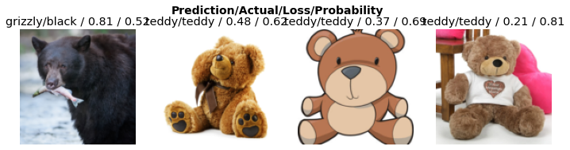

```python
interp.plot_top_losses(4, nrows=1)
```

to be honest, that looks like a grizzly, but i found it from a "black bear" Bing search result and the site it's from has labeled it as a black bear.

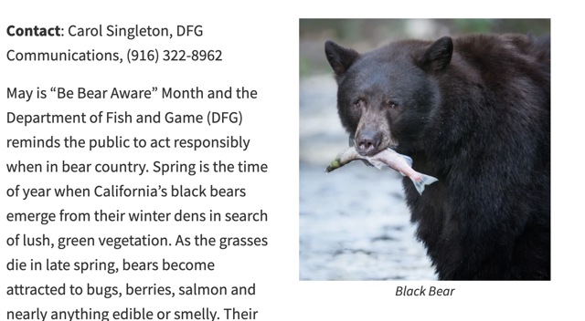

```python
Image.open('black_bear_site.png').to_thumb(640,640)
```

something about it is confusing my learner (and me). what distinguishes a black bear from a brown bear? i found a helpful chart from a google search [source](http://www.bearsmart.com/about-bears/know-the-difference/#:~:text=The%20grizzly%20bear%20has%20a,shoulder%20hump%20and%20smaller%20claws.):

[figure not shown]

```python
Image.open('bear_chart.png').to_thumb(640,640)
```

the ears are tall and pointed and i don't see the shoulder hump. those are two features that the model should recognize but isn't. i'll keep this image in the validation set since it helped me understand what kinds of images confuse the model. i think the color of the fur is what's confusing the model, but i can't say for sure.

## summary

| # of images per class | accuracy |
| --- | --- |
| 10 | 67% |
| 20 | 100% |
| 50 | 86.7% |
| 100 | 98.3% |

the most valuable lesson i learned through these experiments was that an increase an images does not necessarily mean an increase in accuracy (the increase from 20 to 50 images per class reduced accuracy by about 14%). however, there seems to be a greater importance on the variety of images, especially "ambiguous" images (such as the black bear that was mistaken both by me and the model as a grizzly). furthermore, the model did not have any trouble, at any image size, recognizing the difference between a real bear (black or grizzly) and a teddy bear.

## addendum

i was feeding the original bear classifier (with 150 images per class) images of things other than grizzly, black or teddy bears and noticed that it always, with great probability, classified it as a teddy bear. i want to infer the class of non-bear objects to see if there's a pattern. to be clear, i expect the model to classify images of live animals as a grizzly or black bear, and images of inanimate things as a teddy.

```python
Image.open('desk.jpg').to_thumb(128,128)
```

[output not shown]

```python
learn.predict(PILImage.create('desk.jpg'))
```

```
('teddy', tensor(2), tensor([0.1019, 0.2835, 0.6146]))
```

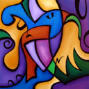

```python
Image.open('abstract_art.jpg').to_thumb(128,128)
```

```python
learn.predict(PILImage.create('abstract_art.jpg'))
```

```
('grizzly', tensor(1), tensor([0.0817, 0.7217, 0.1966]))
```

not sure what activated the grizzly classifier in this abstract art, but it's with a 72% probability.

```python
Image.open('armadillo.jpeg').to_thumb(128,128)
```

[output not shown]

```python
learn.predict(PILImage.create('armadillo.jpeg'))
```

```
('black', tensor(0), tensor([0.7043, 0.1244, 0.1713]))
```

maybe the lack of shoulder hump caused the learner to classify this as a black bear? i'm just kidding.

```python
Image.open('snake.jpg').to_thumb(128,128)
```

[output not shown]

```python
learn.predict(PILImage.create('snake.jpg'))
```

```
('teddy', tensor(2), tensor([0.0579, 0.2738, 0.6683]))
```

i don't know how much meaning i can derive from these results. i'll try some images that in my mind are related to black and grizzly bears.

```python
Image.open('fur1.jpg').to_thumb(128,128)
```

[output not shown]

```python
Image.open('fur2.jpg').to_thumb(128,128)
```

[output not shown]

```python
learn.predict(PILImage.create('fur1.jpg'))
```

```
('grizzly', tensor(1), tensor([0.0486, 0.8992, 0.0522]))
```

```python
learn.predict(PILImage.create('fur2.jpg'))
```

```
('grizzly', tensor(1), tensor([0.1060, 0.8886, 0.0054]))
```

that's...interesting? 89% probability for each.

```python
Image.open('fur3.jpeg').to_thumb(128,128)
```

[output not shown]

```python
Image.open('fur4.jpeg').to_thumb(128,128)
```

[output not shown]

```python
learn.predict(PILImage.create('fur3.jpeg'))
```

```
('black', tensor(0), tensor([0.5833, 0.3423, 0.0744]))
```

```python
learn.predict(PILImage.create('fur4.jpeg'))
```

```
('black', tensor(0), tensor([0.7528, 0.2213, 0.0259]))
```